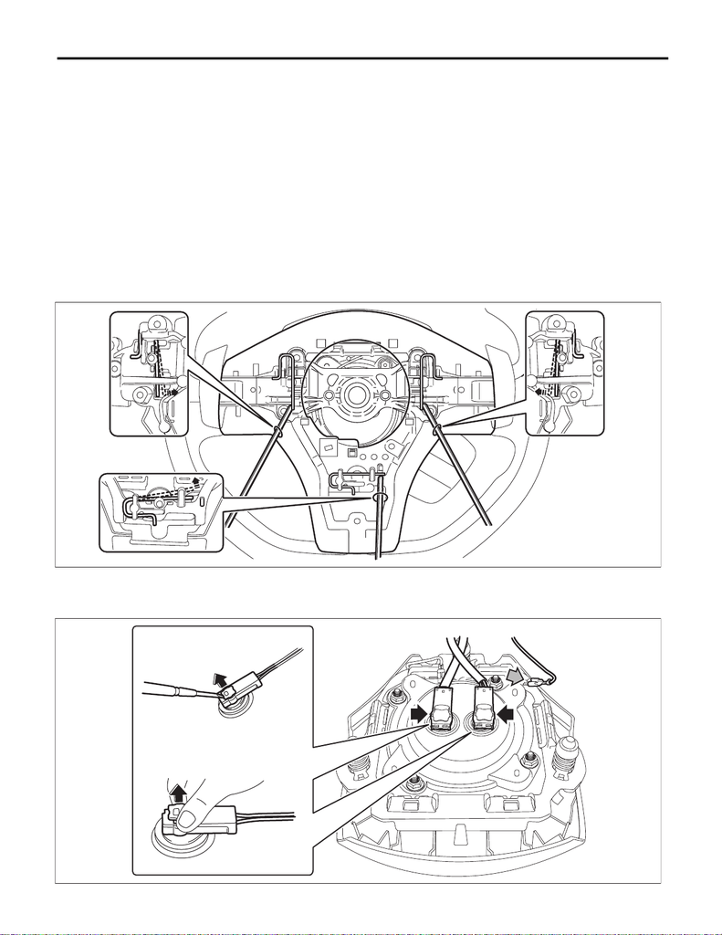

AB-33

Driver’s Airbag Module

AIRBAG SYSTEM

4. Driver’s Airbag Module

A: REMOVAL

CAUTION:

Refer to “CAUTION” of “General Description” before handling the airbag module. <Ref. to AB-9,

CAUTION, General Description.>

1) Position the front wheels straight ahead.

2) Turn the ignition switch to OFF.

3) Disconnect the ground cable from battery and wait for at least 60 seconds before starting work. <Ref. to

NT-5, BATTERY, NOTE, Note.>

NOTE:

For models other than STI model, disconnect the ground terminal from battery sensor.

4) Remove the driver’s airbag module.

(1) Using a hexagon wrench etc. wrapped by protective tape, insert the snap pins and release the locks

(3 locations).

(2) Disconnect the horn harness and airbag connector, and remove the driver’s airbag module. <Ref. to

AB-19, DRIVER’S AIRBAG MODULE, CURTAIN AIRBAG MODULE & PRETENSIONER, PROCE-

DURE, Airbag Connector.>

AB-03490

AB-03544

(1)

(2)

[figure not shown]

AB-34

Driver’s Airbag Module

AIRBAG SYSTEM

B: INSTALLATION

CAUTION:

• Refer to “CAUTION” of “General Description” before handling the airbag module. <Ref. to AB-9,

CAUTION, General Description.>

• Do not allow harness and connectors to interfere or get tangled up with other parts.

1) Before installation, inspect the following items and replace any faulty part with a new one.

• Airbag module is cracked or deformed.

• Harness and/or connector is cracked, deformed or open.

• Harness wire is exposed.

• The steering wheel is in the way, making it difficult to install the airbag module.

• The clearance between the driver’s airbag module and steering wheel is not constant.

2) Install the driver’s airbag module.

(1) Connect the airbag connector to the airbag module securely.

CAUTION:

• Be sure to insert the connector in until it is locked.

• Press in the push lock securely. Then pull it gently to make sure that it is locked.

(2) Connect the horn harness.

(3) Press in the locks (three positions) to install the airbag module.

CAUTION:

Make sure that the airbag module locks (three positions) are securely locked.

3) Connect the battery ground terminal. <Ref. to NT-5, BATTERY, NOTE, Note.>

NOTE:

For models other than STI model, connect the ground terminal to battery sensor.